# Introduction

# Data Wrangling

This data was fairly well-formatted, but it included many strings that required reformatting to be useful to me. I removed variables that showed the same result for all patients because they would be inherently useless as a predictor if both readmitted and non-readmitted patients had the same value.

```python
#Creates a dictionary containing all of the columns as the keys and the values they take as the values.
dictionary = {}
for column in data_trunc:
    if column != 'encounter_id' and column != 'patient_nbr':
        inner_set = set()
        for index, row in data_trunc.iterrows():
            inner_set.add(row[column])
        dictionary[column] =  list(inner_set)

#manual adjustments to dictionary
dictionary['age'] = ['[0-10)', '[10-20)' ,'[20-30)', '[30-40)','[40-50)', '[50-60)', '[60-70)', '[70-80)', '[80-90)',  '[90-100)']
dictionary['insulin'] = ['Steady', 'No', 'Down', 'Up']
dictionary['readmitted'] = [ 'NO', '>30','<30']
```

```python
#removes all of the columns with only 1 entry
remove_list = []

for column in dictionary.keys():
    if len(dictionary[column]) < 2:
        del data_trunc[column]
        remove_list.append(column)

for entry in remove_list:
    dictionary.pop(entry)

data_trunc
```

|  | encounter_id | patient_nbr | race | gender | age | admission_type_id | discharge_disposition_id | admission_source_id | time_in_hospital | medical_specialty | ... | tolbutamide | pioglitazone | rosiglitazone | acarbose | troglitazone | tolazamide | insulin | change | diabetesMed | readmitted |
| --- | --- | --- | --- | --- | --- | --- | --- | --- | --- | --- | --- | --- | --- | --- | --- | --- | --- | --- | --- | --- | --- |
| 0 | 2278392 | 8222157 | Caucasian | Female | [0-10) | 6 | 25 | 1 | 1 | Pediatrics-Endocrinology | ... | No | No | No | No | No | No | No | No | No | NO |
| 1 | 149190 | 55629189 | Caucasian | Female | [10-20) | 1 | 1 | 7 | 3 | ? | ... | No | No | No | No | No | No | Up | Ch | Yes | >30 |
| 2 | 64410 | 86047875 | AfricanAmerican | Female | [20-30) | 1 | 1 | 7 | 2 | ? | ... | No | No | No | No | No | No | No | No | Yes | NO |
| 3 | 500364 | 82442376 | Caucasian | Male | [30-40) | 1 | 1 | 7 | 2 | ? | ... | No | No | No | No | No | No | Up | Ch | Yes | NO |
| 4 | 16680 | 42519267 | Caucasian | Male | [40-50) | 1 | 1 | 7 | 1 | ? | ... | No | No | No | No | No | No | Steady | Ch | Yes | NO |
| ... | ... | ... | ... | ... | ... | ... | ... | ... | ... | ... | ... | ... | ... | ... | ... | ... | ... | ... | ... | ... | ... |
| 995 | 7497384 | 3616155 | Caucasian | Male | [70-80) | 1 | 3 | 7 | 13 | InternalMedicine | ... | No | No | No | No | No | No | Steady | No | Yes | <30 |
| 996 | 7500936 | 1070622 | Caucasian | Male | [0-10) | 2 | 1 | 1 | 1 | Pediatrics-CriticalCare | ... | No | No | No | No | No | No | Steady | No | Yes | NO |
| 997 | 7501614 | 23165379 | Caucasian | Male | [60-70) | 1 | 6 | 7 | 11 | Cardiology | ... | No | No | No | No | No | No | Steady | Ch | Yes | >30 |
| 998 | 7502424 | 4792239 | Caucasian | Female | [70-80) | 1 | 2 | 7 | 12 | Cardiology | ... | No | No | No | No | No | No | Down | Ch | Yes | >30 |
| 999 | 7555146 | 2766582 | Caucasian | Male | [50-60) | 2 | 1 | 1 | 9 | Cardiology | ... | No | No | No | No | No | No | No | Ch | Yes | NO |

1000 rows × 37 columns

```python
#transforms string based variables into integers using the dictionary
for column in dictionary.keys():
        if type(dictionary[column][0]) != int:
            for index, row in data_trunc.iterrows():
                curr = row[column]
                for i in range(len(dictionary[column])):
                    if curr == dictionary[column][i]:
                        data_trunc.at[index, column] = i

data_trunc    #final data
```

|  | encounter_id | patient_nbr | race | gender | age | admission_type_id | discharge_disposition_id | admission_source_id | time_in_hospital | medical_specialty | ... | tolbutamide | pioglitazone | rosiglitazone | acarbose | troglitazone | tolazamide | insulin | change | diabetesMed | readmitted |
| --- | --- | --- | --- | --- | --- | --- | --- | --- | --- | --- | --- | --- | --- | --- | --- | --- | --- | --- | --- | --- | --- |
| 0 | 2278392 | 8222157 | 1 | 1 | 0 | 6 | 25 | 1 | 1 | 16 | ... | 0 | 1 | 1 | 0 | 0 | 0 | 1 | 1 | 0 | 0 |
| 1 | 149190 | 55629189 | 1 | 1 | 1 | 1 | 1 | 7 | 3 | 6 | ... | 0 | 1 | 1 | 0 | 0 | 0 | 3 | 0 | 1 | 1 |
| 2 | 64410 | 86047875 | 4 | 1 | 2 | 1 | 1 | 7 | 2 | 6 | ... | 0 | 1 | 1 | 0 | 0 | 0 | 1 | 1 | 1 | 0 |
| 3 | 500364 | 82442376 | 1 | 0 | 3 | 1 | 1 | 7 | 2 | 6 | ... | 0 | 1 | 1 | 0 | 0 | 0 | 3 | 0 | 1 | 0 |
| 4 | 16680 | 42519267 | 1 | 0 | 4 | 1 | 1 | 7 | 1 | 6 | ... | 0 | 1 | 1 | 0 | 0 | 0 | 0 | 0 | 1 | 0 |
| ... | ... | ... | ... | ... | ... | ... | ... | ... | ... | ... | ... | ... | ... | ... | ... | ... | ... | ... | ... | ... | ... |
| 995 | 7497384 | 3616155 | 1 | 0 | 7 | 1 | 3 | 7 | 13 | 28 | ... | 0 | 1 | 1 | 0 | 0 | 0 | 0 | 1 | 1 | 2 |
| 996 | 7500936 | 1070622 | 1 | 0 | 0 | 2 | 1 | 1 | 1 | 24 | ... | 0 | 1 | 1 | 0 | 0 | 0 | 0 | 1 | 1 | 0 |
| 997 | 7501614 | 23165379 | 1 | 0 | 6 | 1 | 6 | 7 | 11 | 13 | ... | 0 | 1 | 1 | 0 | 0 | 0 | 0 | 0 | 1 | 1 |
| 998 | 7502424 | 4792239 | 1 | 1 | 7 | 1 | 2 | 7 | 12 | 13 | ... | 0 | 1 | 1 | 0 | 0 | 0 | 2 | 0 | 1 | 1 |
| 999 | 7555146 | 2766582 | 1 | 0 | 5 | 2 | 1 | 1 | 9 | 13 | ... | 0 | 1 | 1 | 0 | 0 | 0 | 1 | 0 | 1 | 0 |

1000 rows × 37 columns

```python
#used to transform data for plotting
for index, row in data_trunc.iterrows():
    if row['insulin'] == 'Steady':
        data_trunc.at[index, 'insulin'] = 0
    elif row['insulin'] == 'No':
        data_trunc.at[index, 'insulin'] = 1
    elif row['insulin'] ==  'Down':
        data_trunc.at[index, 'insulin'] = 2
    elif row['insulin'] == 'Up':
        data_trunc.at[index, 'insulin'] = 3

    if row['diabetesMed'] == 'No':
        data_trunc.at[index, 'diabetesMed'] = 0
    elif row['diabetesMed'] == 'Yes':
        data_trunc.at[index, 'diabetesMed'] = 1

    #readmitted column
    if row['readmitted'] == 'NO':
        data_trunc.at[index, 'readmitted'] = 0
    elif row['readmitted'] == '>30':
        data_trunc.at[index, 'readmitted'] = 1
    elif row['readmitted'] == '<30':
        data_trunc.at[index, 'readmitted'] = 2

    if row['gender'] == 'Female':
        data_trunc.at[index, 'gender'] = 0
    elif row['gender'] == 'Male':
        data_trunc.at[index, 'gender'] = 1

    if row['race'] == 'Asian':
        data_trunc.at[index, 'race'] = 0
    elif row['race'] == 'AfricanAmerican':
        data_trunc.at[index, 'race'] = 1
    elif row['race'] == 'Other':
        data_trunc.at[index, 'race'] = 2
    elif row['race'] == 'Hispanic':
        data_trunc.at[index, 'race'] = 3
    elif row['race'] == 'Caucasian':
        data_trunc.at[index, 'race'] = 4
    elif row['race'] == '?':
        data_trunc.at[index, 'race'] = 5
```

```python
#Used to
insulin_1_list = [0] * len(dictionary['age'])
insulin_2_list = [0] * len(dictionary['age'])
insulin_3_list = [0] * len(dictionary['age'])
insulin_4_list = [0] * len(dictionary['age'])


readmitted_1_list = [0] * len(dictionary['age'])
readmitted_2_list = [0] * len(dictionary['age'])
readmitted_3_list = [0] * len(dictionary['age'])

num_age_list = [0] * len(dictionary['age'])

for index, row in data_trunc.iterrows():
    age_index = row['age']

    num_age_list[age_index] += 1

    if row['insulin'] == 0:
        insulin_1_list[age_index] += 1
    if row['insulin'] == 1:
        insulin_2_list[age_index] += 1
    if row['insulin'] == 2:
        insulin_3_list[age_index] += 1
    if row['insulin'] == 3:
        insulin_4_list[age_index] += 1

    if row['readmitted'] == 0:
        readmitted_1_list[age_index] += 1
    if row['readmitted'] == 1:
        readmitted_2_list[age_index] += 1
    if row['readmitted'] == 2:
        readmitted_3_list[age_index] += 1

for index in range(len(num_age_list)):
    insulin_1_list[index] = insulin_1_list[index]/num_age_list[index]
    insulin_2_list[index] = insulin_2_list[index]/num_age_list[index]
    insulin_3_list[index] = insulin_3_list[index]/num_age_list[index]
    insulin_4_list[index] = insulin_4_list[index]/num_age_list[index]

    readmitted_1_list[index] = readmitted_1_list[index]/num_age_list[index]
    readmitted_2_list[index] = readmitted_2_list[index]/num_age_list[index]
    readmitted_3_list[index] = readmitted_3_list[index]/num_age_list[index]
```

# Data Exploration

I used seven graphs to explore relationships between variables in the data set and I calculated correlations between the variables that were graphed.

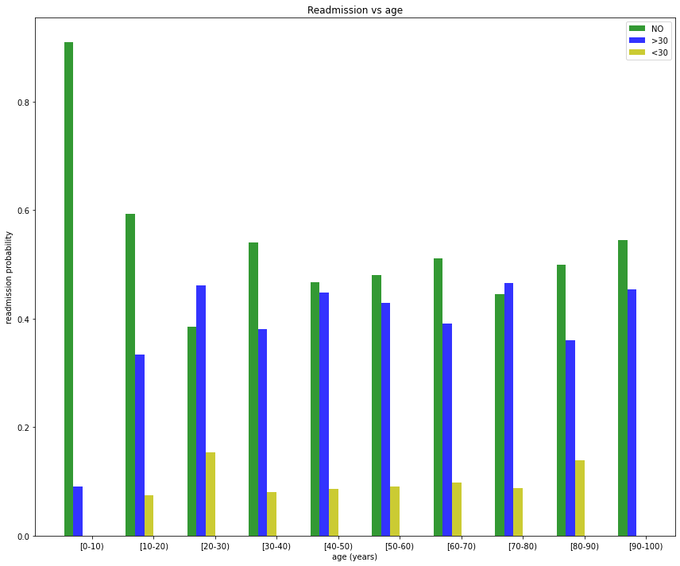

```
[[1.         0.04370889]
 [0.04370889 1.        ]]
```

```python
#plot readmission vs age
fig, ax = plt.subplots()
index = np.arange(len(dictionary['age']))
bar_width = 0.15
opacity = 0.8

fig.set_figwidth(12)
fig.set_figheight(10)


plt.bar(index - bar_width * 1.5, readmitted_1_list, bar_width, alpha=opacity, color='g', label=dictionary['readmitted'][0])

plt.bar(index - bar_width * 0.5, readmitted_2_list, bar_width, alpha=opacity, color='b', label=dictionary['readmitted'][1])

plt.bar(index + bar_width * 0.5, readmitted_3_list, bar_width, alpha=opacity, color='y', label=dictionary['readmitted'][2])

plt.xlabel('age (years)')
plt.ylabel('readmission probability')
plt.title('Readmission vs age')
plt.xticks(index + bar_width, dictionary['age'])
plt.legend()

plt.tight_layout()
plt.show()
print(np.corrcoef(data_trunc['age'].tolist(), data_trunc['readmitted'].tolist()))
```

Although this plot demonstrates an apparent age versus readmission probability, the correlation tells us that the relationship is weak, indicating that it provides no insight into potential hospital readmission.

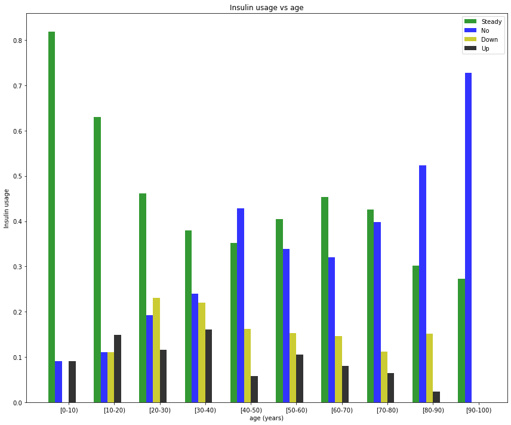

```
[[ 1.         -0.02911685]
 [-0.02911685  1.        ]]
```

```python
# create plot

fig, ax = plt.subplots()
index = np.arange(len(dictionary['age']))
bar_width = 0.15
opacity = 0.8

fig.set_figwidth(12)
fig.set_figheight(10)


rects1 = plt.bar(index - bar_width * 1.5, insulin_1_list, bar_width, alpha=opacity, color='g', label=dictionary['insulin'][0])

rects2 = plt.bar(index - bar_width * 0.5, insulin_2_list, bar_width, alpha=opacity, color='b', label=dictionary['insulin'][1])#

rects3 = plt.bar(index + bar_width * 0.5, insulin_3_list, bar_width, alpha=opacity, color='y', label=dictionary['insulin'][2])

rects4 = plt.bar(index + bar_width * 1.5, insulin_4_list, bar_width, alpha=opacity, color='black', label=dictionary['insulin'][3])

plt.xlabel('age (years)')
plt.ylabel('Insulin usage')
plt.title('Insulin usage vs age')
plt.xticks(index + bar_width, dictionary['age'])
plt.legend()

plt.tight_layout()
plt.show()
print(np.corrcoef(data_trunc['age'].tolist(), data_trunc['insulin'].tolist()))
```

```
[[1.         0.04545016]
 [0.04545016 1.        ]]
```

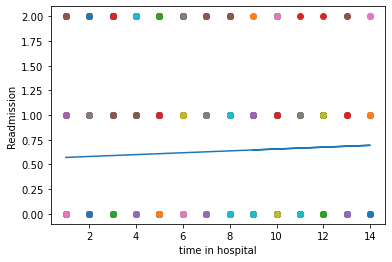

```python
#time in hospital vs readmission
fig4, axs4 = plt.subplots()

x_list=[]
y_list=[]

for index, row in data_trunc.iterrows():
            point_marker='o'

            axs4.scatter(row['time_in_hospital'], row['readmitted'], marker=point_marker)
            x_list.append(row['time_in_hospital'])
            y_list.append(row['readmitted'])
            #oint_marker='s'

print(np.corrcoef(x_list, y_list))
#print(x_list, y_list)
trend = np.polyfit(x_list, y_list, 1)
trendpoly = np.poly1d(trend)
axs4.plot(x_list, trendpoly(x_list))

plt.xlabel('time in hospital')
plt.ylabel('Readmission')
```

```
[[ 1.         -0.08771659]
 [-0.08771659  1.        ]]
```

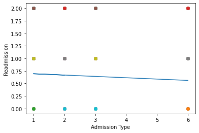

```python
#admission_type vs readmission
fig4, axs4 = plt.subplots()

x_list=[]
y_list=[]

for index, row in data_trunc.iterrows():
            point_marker='o'

            axs4.scatter(row['admission_type_id'], row['readmitted'], marker=point_marker)
            x_list.append(row['admission_type_id'])
            y_list.append(row['readmitted'])

print(np.corrcoef(x_list, y_list))
trend = np.polyfit(x_list, y_list, 1)
trendpoly = np.poly1d(trend)
axs4.plot(x_list, trendpoly(x_list))


plt.xlabel('Admission Type')
plt.ylabel('Readmission')
```

```
[[ 1.         -0.08223696]
 [-0.08223696  1.        ]]
```

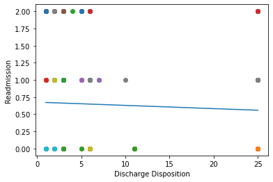

```python
#discharge_disposition_id vs readmission
fig4, axs4 = plt.subplots()

x_list=[]
y_list=[]

for index, row in data_trunc.iterrows():
            point_marker='o'

            axs4.scatter(row['discharge_disposition_id'], row['readmitted'], marker=point_marker)
            x_list.append(row['discharge_disposition_id'])
            y_list.append(row['readmitted'])


print(np.corrcoef(x_list, y_list))
trend = np.polyfit(x_list, y_list, 1)
trendpoly = np.poly1d(trend)
axs4.plot(x_list, trendpoly(x_list))


plt.xlabel('Discharge Disposition')
plt.ylabel('Readmission')
```

```
[[1.        0.0194877]
 [0.0194877 1.       ]]
```

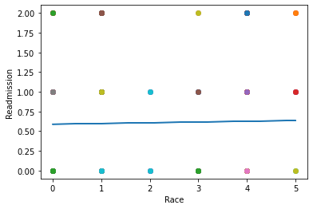

```python
#race vs readmission
fig4, axs4 = plt.subplots()

x_list=[]
y_list=[]

for index, row in data_trunc.iterrows():
            point_marker='o'

            axs4.scatter(row['race'], row['readmitted'], marker=point_marker)
            x_list.append(row['race'])
            y_list.append(row['readmitted'])


print(np.corrcoef(x_list, y_list))
trend = np.polyfit(x_list, y_list, 1)
trendpoly = np.poly1d(trend)
axs4.plot(x_list, trendpoly(x_list))

plt.xlabel('Race')
plt.ylabel('Readmission')
```

```
[[1.         0.04124326]
 [0.04124326 1.        ]]
```

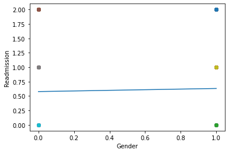

```python
#gender vs readmission
fig4, axs4 = plt.subplots()

x_list=[]
y_list=[]

for index, row in data_trunc.iterrows():
            point_marker='o'

            axs4.scatter(row['gender'], row['readmitted'], marker=point_marker)
            x_list.append(row['gender'])
            y_list.append(row['readmitted'])

print(np.corrcoef(x_list, y_list))
trend = np.polyfit(x_list, y_list, 1)
trendpoly = np.poly1d(trend)
axs4.plot(x_list, trendpoly(x_list))

plt.xlabel('Gender')
plt.ylabel('Readmission')
```